# from-spreadsheets-to-pandas

### More complex visualizations

Many visualizations are easier to make if we first need to reshape our data frame into the [tidy or long data format](http://vita.had.co.nz/papers/tidy-data.pdf), which is the format `seaborn` prefers. This is sometimes referred to as changing the data from wide to long format, and moves some of the information from columns to rows:

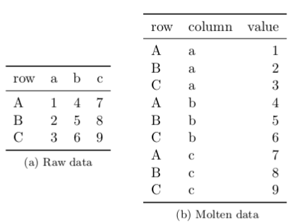

```python
Image('./molten-data.png') # Image from http://vita.had.co.nz/papers/tidy-data.pdf
```

We can use pandas built-in `melt`-function to transform the data into the long format. The new columns will be given the names `variable` and `value` (see the help of `melt` if you would like to change these names).

```python
iris_melt = pd.melt(iris, id_vars='species')
iris_melt
```

|  | species | variable | value |
| --- | --- | --- | --- |
| 0 | setosa | sepal_length | 5.1 |
| 1 | setosa | sepal_length | 4.9 |
| 2 | setosa | sepal_length | 4.7 |
| 3 | setosa | sepal_length | 4.6 |
| 4 | setosa | sepal_length | 5.0 |
| ... | ... | ... | ... |
| 595 | virginica | petal_width | 2.3 |
| 596 | virginica | petal_width | 1.9 |
| 597 | virginica | petal_width | 2.0 |
| 598 | virginica | petal_width | 2.3 |
| 599 | virginica | petal_width | 1.8 |

600 rows × 3 columns

We do not need to call `groupby` or `mean` on the long `iris`-dataframe when plotting with `seaborn`. Instead we control these options from `seaborn` with the plot type we chose (barplot = mean automatically) and the `hue`-parameter, which is analogous to `groupby`.

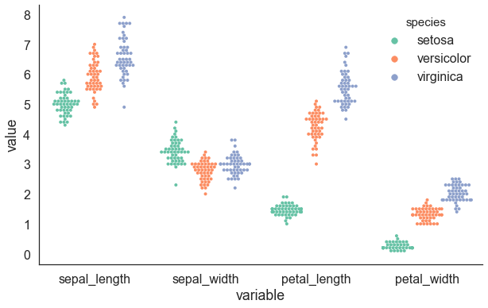

```python
sns.set(context='poster', style='white', rc={'figure.figsize':(10, 6)})

sns.swarmplot(x='variable', y='value', hue='species', data=iris_melt, dodge=True, palette='Set2', size=4)
sns.despine() # removes the right and top black border
```

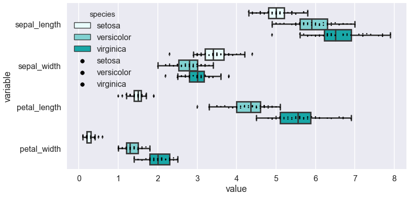

```python
sns.set(context='poster', style='darkgrid', rc={'figure.figsize':(12, 6)})

sns.boxplot(y='variable', x='value', hue='species', data=iris_melt, color='c', )
sns.stripplot(y='variable', x='value', hue='species', data=iris_melt, size=2.5, palette=['k']*3, jitter=True, dodge=True)
sns.despine(trim=True)
```

It is also possible to get too fancy and accidentally hide important messages in the data. However, the fact that you now have access to several ways to plot your data forces you to consider what is actually important and how you can best communicate that message, rather than always making the same plot without considering its strengths and weaknesses.

# Resources to learn more

The documentation for these packages are great resources to learn more.

- [Introduction to `pandas`](http://pandas.pydata.org/pandas-docs/stable/10min.html)
- [Lessons for new `pandas` users](http://pandas.pydata.org/pandas-docs/stable/tutorials.html#lessons-for-new-pandas-users)
- [The `seaborn` gallery](http://seaborn.pydata.org/examples/index.html)
- [The `seaborn` tutorials](http://seaborn.pydata.org/tutorial.html)
- [The `matplotlib` gallery](http://matplotlib.org/gallery.html) is another great resource. We did not practice using `matplotlib` explicitly in this notebook, but the plotting techniques from `pandas` and `seaborn` are layers on top of the `matplotlib` library, so we have been using it indirectly.